# The most popular Pirate101 class

## What is Pirate101?

Pirate101 is a online MMORPG made by Kingsisle Entertainment who also made wizard101. Released in 2012, pirate101 is a pirate themed adventure game with turn based combat based on a grid based game play which was a pivotal part of my childhood. The game offers 5 different classes for players to choose from the Buccaneer, Musketeer, Privateer, Swashbuckler, and the Witchdoctor each with its own unique playstyle.

## My goal

I wanted to figure out if there was a certain more favored class among pirate101 players. I did this by logging the number of players of each class in a server at a certain time in Avery’s Court which is usually the most populated area of pirate101; I then proceeded to switch servers and do the same thing again. Below is a GIF showing an example of the process.

[figure not shown]

A GIF showing a small sample of data entrees

## Which class is the most popular?

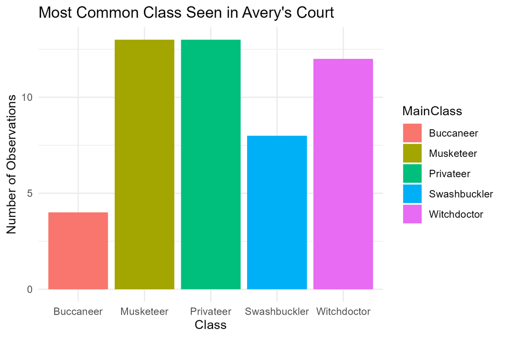

A bar chart depicting the totals of which class was the most seen

Key points about this chart:

- Out of the 50 data logs, Musketeers and Privateers tied at 13 entries of having the most players.
- Buccaneers were the least popular with only 4 entries of them having the most players.
- Buccaneers and Swashbucklers seem the least popular as the Musketeers, Privateers, and Witchdoctors have similar scores.

## Findings

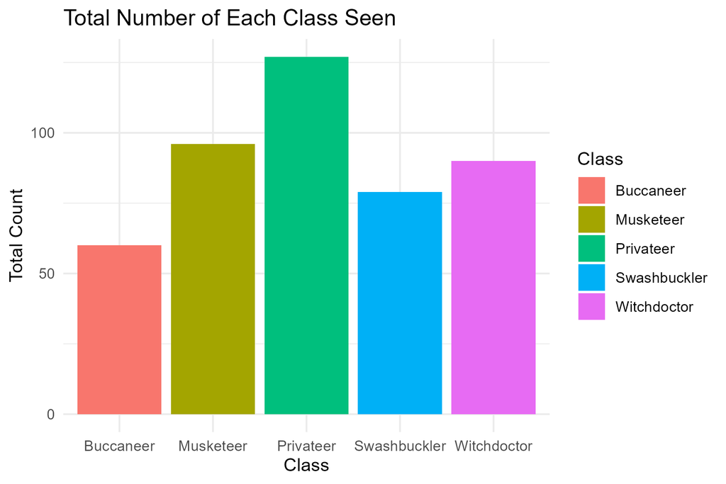

This is a bar chart showing the total number of payers for each class recorded. Compared to the bar chart above showing the class with the most players in a server, this chart shows a completely different story. Although musketeers, privateers, and witchdoctors in the bar chart showing the most popular class in each server are all pretty similar, the chart for total number of players shows that privateers are far ahead of both musketeers and witchdoctors by at least 25 players. This means that although in some servers there were more of another class than privateers on average there were more privateers across all servers as there was a total of 127 privateer players observed over 50 instances for an average of 2.54 per observation. And on the other hand buccaneers only had a total of 60 players across 50 entries meaning there was an average of 1.2 buccaneer players per observation.

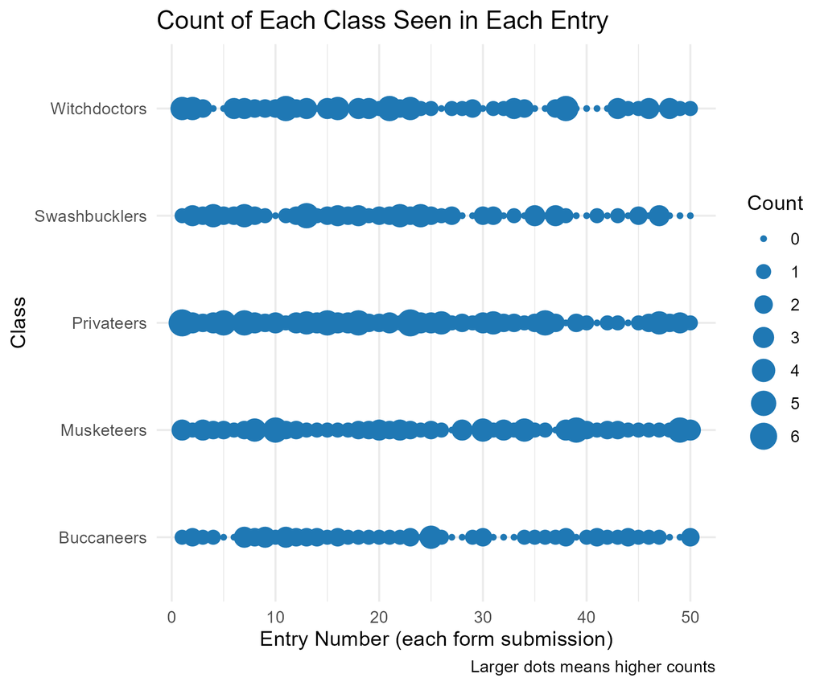

A dot plot of the number of pirates seen per class in each observation

This is a dot plot showing the number of pirates of each class seen in each observation where larger dots mean more pirates of that class in a single obervation. Privateers and musketeers tend to have slightly larger fots overall meaning they’re more often seen. Buccaneers tend to have smaller dots and also have an inconsistent line compared to other classes.

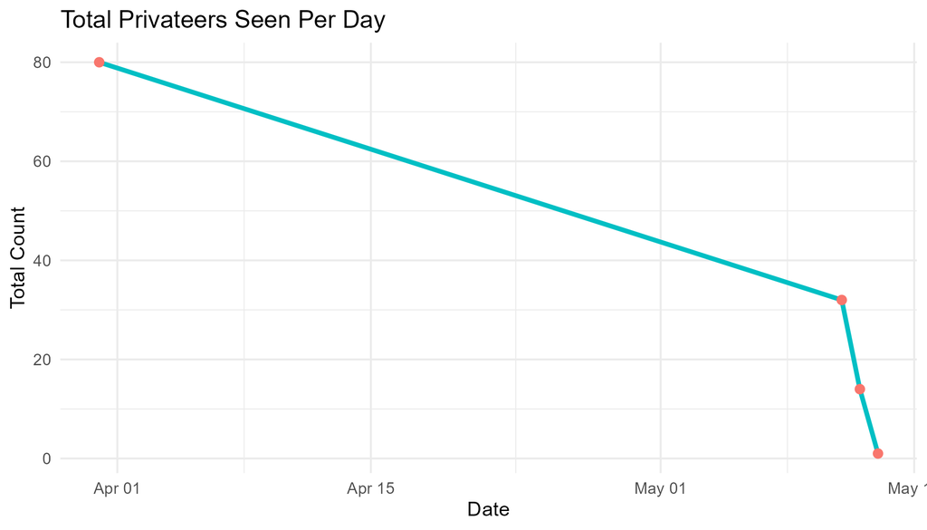

This is a line chart showing the total number of privateers observed in different time periods. The x-axis represents the time in daily groups ranging from march 31st to may 13th and the y-axis represents the total count of privateers seen. Each point represents a specific day the observations were made.

## Conclusion

In conclusion, there does tend to be a small bias towards privateers for players as on average there are more privateers players in total especially compared to buccaneers where there were observed to be more than twice as many privateer players than buccaneer players. While musketeers and witchdoctors also appear consistently but not as much as privateer players. With how privateers lean towards a more supportive playstyle granting benefits to the team these results emphasize how pirate101 players are nice at heart and therefore you should play pirate101.